# Modelling workshop: Session 5

##### Mixed models

Last in this session, we will see what happens if we do not know what the **truth** is, by using models to find cut offs. We can do that using a **mixed model**.

A mixed model can be used to find the cut offs between two **bimodal distribution peaks**.

In this case, the mixed model involves fitting two *Gaussian distributions* or *normal* distributions to the data, with each distribution corresponding to one of the bimodal peaks. The means and standard deviations of each distribution would be modeled as fixed effects, while the within-subject variability would be modeled as a random effect.

The mixed model also includes a binary variable indicating which of the two distributions each observation belongs to. The cut off point between the two distributions is estimated as the point where the probability of belonging to each distribution is equal.

Mixed models can be fit using **maximum likelihood** estimation, and model selection by methods such as **Akaike’s Information Criterion** (AIC) or **Bayesian** methods and **Bayesian Information Criterion** (BIC) could be used to determine the best model. We will cover these better in **Session 7**.

Once the model is fit, the cut off point between the two bimodal peaks can be estimated, along with confidence intervals or credible intervals. This information can then be used to identify the groups or subgroups within the data that correspond to each of the bimodal peaks, and to further explore the differences between these groups or subgroups.

Here is some R code that simulates a *bimodal distribution* and fits a mixture model to estimate the cut-off point where we use two **normal** distributions and a *maximum likelihood* approach:

```r
# Simulate data from a bimodal distribution
set.seed(123)
n <- 1000
x <- c(rnorm(n/2, mean = 2, sd = 1), rnorm(n/2, mean = 6, sd = 1))
pop <- c(rep(1,n/2),rep(2,n/2))
# Fit mixture model to data
library(mixtools)
model <- normalmixEM(x)
```

```
## number of iterations= 27
```

```r
# Find optimal cutoff between peaks
cutoff <- (model$mu[1] + model$mu[2]) / 2

# Calculate sensitivity and specificity for different cutoff values
sensitivity <- numeric(length(x))
specificity <- numeric(length(x))

for (i in 1:length(x)) {
  predicted <- x > x[i]
  true_positives <- sum(predicted & (x >= cutoff))
  false_negatives <- sum(!predicted & (x >= cutoff))
  true_negatives <- sum(!predicted & (x < cutoff))
  false_positives <- sum(predicted & (x < cutoff))
  sensitivity[i] <- true_positives / (true_positives + false_negatives)
  specificity[i] <- true_negatives / (true_negatives + false_positives)
}

# Find cutoff value with highest sum of sensitivity and specificity
best_cutoff <- x[which.max(sensitivity + specificity)]
best_cutoff
```

```
## [1] 3.975419
```

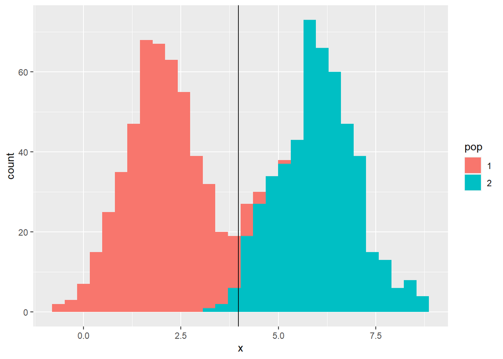

```r
# plot x with the cut off

xx<-data.frame(x=x,pop=as.factor(pop))
library(ggplot2)
p <- ggplot(xx, aes(x = x, fill = pop)) + geom_histogram()+
  geom_vline(xintercept = best_cutoff, col = 'black')
p
```

You can see that some red and some blue points are either side of the cut off in black, showing the false positives and negatives if this was the chosen cut off.

Now let’s re-run the code with different cut offs and make news plots called p1 and p2 that we will save and plot after running the code:

```r
# Simulate data from a bimodal distribution
set.seed(123)
n <- 1000
x1 <- c(rnorm(n/2, mean = 2, sd = 1), rnorm(n/2, mean = 4, sd = 1))
pop <- c(rep(1,n/2),rep(2,n/2))

# Fit mixture model to data
library(mixtools)
model <- normalmixEM(x1)
```

```
## number of iterations= 253
```

```r
# Find optimal cutoff between peaks
cutoff <- (model$mu[1] + model$mu[2]) / 2

# Calculate sensitivity and specificity for different cutoff values
sensitivity <- numeric(length(x1))
specificity <- numeric(length(x1))

for (i in 1:length(x1)) {
  predicted <- x1 > x1[i]
  true_positives <- sum(predicted & (x1 >= cutoff))
  false_negatives <- sum(!predicted & (x1 >= cutoff))
  true_negatives <- sum(!predicted & (x1 < cutoff))
  false_positives <- sum(predicted & (x1 < cutoff))
  sensitivity[i] <- true_positives / (true_positives + false_negatives)
  specificity[i] <- true_negatives / (true_negatives + false_positives)
}

# Find cutoff value with highest sum of sensitivity and specificity
best_cutoff <- x1[which.max(sensitivity + specificity)]
best_cutoff
```

```
## [1] 2.941409
```

```r
# plot x with the cut off

xx1<-data.frame(x=x1,pop=as.factor(pop))
library(ggplot2)
p1 <- ggplot(xx1, aes(x = x, fill = pop)) + geom_histogram()+
  geom_vline(xintercept = best_cutoff, col = 'black')
```

And p2

```r
# Simulate data from a bimodal distribution
set.seed(123)
n <- 1000
x2 <- c(rnorm(n/2, mean = 2, sd = 1), rnorm(n/2, mean = 6, sd = 3))
pop <- c(rep(1,n/2),rep(2,n/2))

model <- normalmixEM(x2)
```

```
## number of iterations= 48
```

```r
# Find optimal cutoff between peaks
cutoff <- (model$mu[1] + model$mu[2]) / 2

# Calculate sensitivity and specificity for different cutoff values
sensitivity <- numeric(length(x2))
specificity <- numeric(length(x2))

for (i in 1:length(x2)) {
  predicted <- x2 > x2[i]
  true_positives <- sum(predicted & (x2 >= cutoff))
  false_negatives <- sum(!predicted & (x2 >= cutoff))
  true_negatives <- sum(!predicted & (x2 < cutoff))
  false_positives <- sum(predicted & (x2 < cutoff))
  sensitivity[i] <- true_positives / (true_positives + false_negatives)
  specificity[i] <- true_negatives / (true_negatives + false_positives)
}

# Find cutoff value with highest sum of sensitivity and specificity
best_cutoff <- x2[which.max(sensitivity + specificity)]
best_cutoff
```

```
## [1] 4.050085
```

```r
# plot x with the cut off


xx2<-data.frame(x=x2,pop=as.factor(pop))
library(ggplot2)
p2 <- ggplot(xx2, aes(x = x, fill = pop)) + geom_histogram()+
  geom_vline(xintercept = best_cutoff, col = 'black')
```

And let’s plot them together:

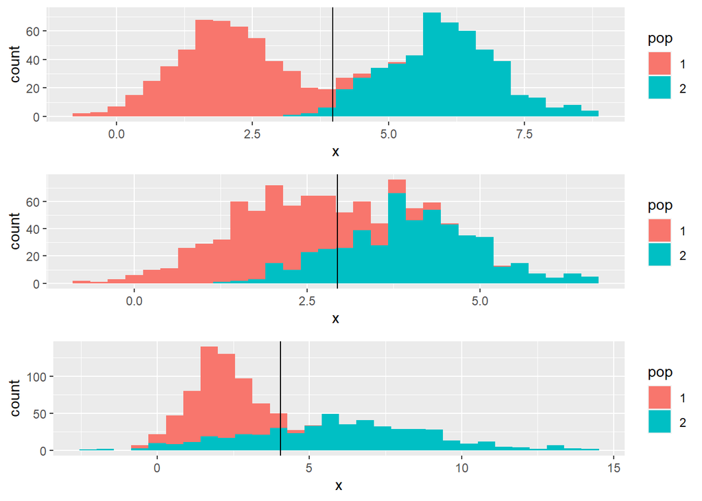

```r
library(ggpubr)
ggarrange(p,p1,p2, ncol = 1)
```

Here we can see that there are different numbers of each either side of the threshold line in black, depending on the distributions and cut offs used.

Note of course that there will be *no negative titres* for tests such as on the Luminex platform, but these modelling approaches generally will work well and there are different models that can be fit to data.

Last we can use these types of data to determine what is and what is not over and above a threshold. For example, with our original example data let’s make a new column saying whether the *IgG_S* titre is over 10.3, which we used in an example above.

```r
library(tidyverse)

# add the threshold, e.g.
example_data$threshold <- 10.3


# use mutate to create new column based on threshold
example_data <- example_data %>%
  mutate(over_threshold = ifelse(IgG_S > threshold, "over", "not over"))

# view updated data frame
glimpse(example_data)
```

```
## Rows: 51
## Columns: 26
## $ Patient                            <int> 639064, 639220, 639265, 639301, 639…
## $ Cohort                             <fct> mild, mild, mild, mild, mild, mild,…
## $ Clinical.features                  <chr> "-", "-", "-", "-", "-", "-", "-", …
## $ Date.of.birth                      <date> 1943-03-15, 1934-01-24, 1981-10-17…
## $ Age                                <int> 77, 86, 39, 15, 0, 90, 62, 16, 34, …
## $ Sex                                <fct> M, M, F, F, M, F, M, F, F, F, F, F,…
## $ Date.of.symptoms                   <date> 2020-03-10, NA, 2020-03-27, 2020-0…
## $ Date.of.PCR.test                   <date> 2020-03-11, 2020-03-24, 2020-03-28…
## $ Date.of.blood.sample               <date> 2020-04-15, 2020-04-20, 2020-04-22…
## $ Time.from.PCR.to.blood.sample      <int> 35, 27, 25, 15, 2, 8, 16, 15, 18, 2…
## $ Time.from.symptoms.to.blood.sample <int> 36, NA, 26, 16, 3, 9, 16, NA, 19, 3…
## $ IgG.Beckman                        <dbl> 0.21, 51.07, 8.84, 15.57, 1.81, 30.…
## $ Result.Beckman                     <fct> NEG, POS, POS, POS, POS, POS, POS, …
## $ Total.Ab.Roche                     <dbl> 0.082, 86.660, 21.910, 5.440, 21.17…
## $ Result.Roche                       <fct> NEG, POS, POS, POS, POS, POS, POS, …
## $ IgG_S                              <dbl> 2.023055, 56.576121, 21.959659, 59.…
## $ IgG_E                              <dbl> 1.1436107, 1.1660746, 1.2281292, 1.…
## $ IgG_M                              <dbl> 1.1493747, 3.5215789, 1.5202583, 1.…
## $ IgM_S                              <dbl> 1.144476, 24.310832, 5.159334, 8.26…
## $ IgM_E                              <dbl> 1.017370, 1.268121, 1.292214, 1.361…
## $ IgM_M                              <dbl> 1.1125156, 2.6435373, 1.6662231, 1.…
## $ IgA_S                              <dbl> 1.148983, 13.988333, 6.302265, 4.41…
## $ IgA_E                              <dbl> 1.0827552, 1.0315657, 1.0192143, 1.…
## $ IgA_M                              <dbl> 1.2171865, 2.3856531, 1.5634358, 1.…
## $ threshold                          <dbl> 10.3, 10.3, 10.3, 10.3, 10.3, 10.3,…
## $ over_threshold                     <chr> "not over", "over", "over", "over",…
```

Take a look at the last lines of the printed data.